# Clustering the Market Segments

### Project details:

#### Project: Clustering the Market Segments

#### Data: Clustering the Market Segments.csv

#### Description:

One way to gain an edge in segmented marketing to identify segments of people who share similar tastes, so that they can avoid targeting advertisements to people with no interest in the product being sold. For instance, an alcoholic beverage is likely to be difficult to sell to people who do not drink. Given the text of Social Networking Service (SNS) pages of people, we can identify groups that share common interests such as sports, religion, or music. Clustering can automate the process of discovering the natural segments in this population.

#### Objective:

- Cluster a number of products, with related products in one segment

#### Guidelines:

- Explore and prepare the data
- Coding the missing values
- Imputation on missing values
- Training model on data
- Evaluation of model performance and visualization of segments.

```r
library(tidyr)
library(dplyr)
library(ggplot2)
library(caret)
library(pROC)
```

### Loading the data

```r
market <- read.csv('clustering the Market Segments.csv')
str(market)
```

```
## 'data.frame':    15070 obs. of  40 variables:
##  $ gradyear    : int  2006 2006 2006 2006 2006 2006 2006 2006 2006 2006 ...
##  $ gender      : Factor w/ 2 levels "F","M": 2 1 2 1 NA 1 1 2 1 1 ...
##  $ age         : num  19 18.8 18.3 18.9 19 ...
##  $ friends     : int  7 0 69 0 10 142 72 17 52 39 ...
##  $ basketball  : int  0 0 0 0 0 0 0 0 0 0 ...
##  $ football    : int  0 1 1 0 0 0 0 0 0 0 ...
##  $ soccer      : int  0 0 0 0 0 0 0 0 0 0 ...
##  $ softball    : int  0 0 0 0 0 0 0 1 0 0 ...
##  $ volleyball  : int  0 0 0 0 0 0 0 0 0 0 ...
##  $ swimming    : int  0 0 0 0 0 0 0 0 0 0 ...
##  $ cheerleading: int  0 0 0 0 0 0 0 0 0 0 ...
##  $ baseball    : int  0 0 0 0 0 0 0 0 0 0 ...
##  $ tennis      : int  0 0 0 0 0 0 0 0 0 0 ...
##  $ sports      : int  0 0 0 0 0 0 0 0 0 0 ...
```

[output cut: 26 more lines]

### check missing values

```r
summary(market)
```

```
##     gradyear     gender           age             friends
##  Min.   :2006   F   :10749   Min.   :  3.086   Min.   :  0.00
##  1st Qu.:2006   M   : 2893   1st Qu.: 17.662   1st Qu.:  2.00
##  Median :2007   NA's: 1428   Median : 18.209   Median : 18.00
##  Mean   :2007                Mean   : 18.756   Mean   : 28.28
##  3rd Qu.:2007                3rd Qu.: 18.716   3rd Qu.: 41.00
##  Max.   :2008                Max.   :106.927   Max.   :830.00
##                              NA's   :2400
##    basketball         football           soccer           softball
##  Min.   : 0.0000   Min.   : 0.0000   Min.   : 0.0000   Min.   : 0.0000
##  1st Qu.: 0.0000   1st Qu.: 0.0000   1st Qu.: 0.0000   1st Qu.: 0.0000
##  Median : 0.0000   Median : 0.0000   Median : 0.0000   Median : 0.0000
##  Mean   : 0.2149   Mean   : 0.2322   Mean   : 0.1788   Mean   : 0.1271
##  3rd Qu.: 0.0000   3rd Qu.: 0.0000   3rd Qu.: 0.0000   3rd Qu.: 0.0000
##  Max.   :24.0000   Max.   :11.0000   Max.   :22.0000   Max.   :15.0000
##
##    volleyball         swimming        cheerleading        baseball
##  Min.   : 0.0000   Min.   : 0.0000   Min.   :0.00000   Min.   : 0.00000
##  1st Qu.: 0.0000   1st Qu.: 0.0000   1st Qu.:0.00000   1st Qu.: 0.00000
##  Median : 0.0000   Median : 0.0000   Median :0.00000   Median : 0.00000
##  Mean   : 0.1084   Mean   : 0.1165   Mean   :0.08826   Mean   : 0.09118
##  3rd Qu.: 0.0000   3rd Qu.: 0.0000   3rd Qu.:0.00000   3rd Qu.: 0.00000
##  Max.   :11.0000   Max.   :10.0000   Max.   :9.00000   Max.   :16.00000
##
##      tennis             sports             cute              sex
##  Min.   : 0.00000   Min.   : 0.0000   Min.   : 0.0000   Min.   :  0.0000
##  1st Qu.: 0.00000   1st Qu.: 0.0000   1st Qu.: 0.0000   1st Qu.:  0.0000
##  Median : 0.00000   Median : 0.0000   Median : 0.0000   Median :  0.0000
##  Mean   : 0.08607   Mean   : 0.1222   Mean   : 0.3047   Mean   :  0.2143
##  3rd Qu.: 0.00000   3rd Qu.: 0.0000   3rd Qu.: 0.0000   3rd Qu.:  0.0000
##  Max.   :13.00000   Max.   :12.0000   Max.   :18.0000   Max.   :114.0000
##
##       sexy              hot               kissed             dance
##  Min.   : 0.0000   Min.   : 0.00000   Min.   : 0.00000   Min.   : 0.0000
##  1st Qu.: 0.0000   1st Qu.: 0.00000   1st Qu.: 0.00000   1st Qu.: 0.0000
##  Median : 0.0000   Median : 0.00000   Median : 0.00000   Median : 0.0000
##  Mean   : 0.1223   Mean   : 0.09801   Mean   : 0.09356   Mean   : 0.3707
##  3rd Qu.: 0.0000   3rd Qu.: 0.00000   3rd Qu.: 0.00000   3rd Qu.: 0.0000
##  Max.   :18.0000   Max.   :10.00000   Max.   :26.00000   Max.   :30.0000
##
```

[output cut: 25 more lines]

```
##  Min.   :0.000   Min.   :0.0000   Min.   :0.00000   Min.   :0.00000
##  1st Qu.:0.000   1st Qu.:0.0000   1st Qu.:0.00000   1st Qu.:0.00000
##  Median :0.000   Median :0.0000   Median :0.00000   Median :0.00000
##  Mean   :0.325   Mean   :0.1328   Mean   :0.05209   Mean   :0.03869
##  3rd Qu.:0.000   3rd Qu.:0.0000   3rd Qu.:0.00000   3rd Qu.:0.00000
##  Max.   :8.000   Max.   :8.0000   Max.   :9.00000   Max.   :6.00000
##                                                     NA's   :1
##       die              death             drunk             drugs
##  Min.   : 0.0000   Min.   : 0.0000   Min.   :0.00000   Min.   : 0.00000
##  1st Qu.: 0.0000   1st Qu.: 0.0000   1st Qu.:0.00000   1st Qu.: 0.00000
##  Median : 0.0000   Median : 0.0000   Median :0.00000   Median : 0.00000
##  Mean   : 0.1782   Mean   : 0.1146   Mean   :0.09576   Mean   : 0.05694
##  3rd Qu.: 0.0000   3rd Qu.: 0.0000   3rd Qu.:0.00000   3rd Qu.: 0.00000
##  Max.   :22.0000   Max.   :14.0000   Max.   :8.00000   Max.   :16.00000
##  NA's   :1         NA's   :1         NA's   :1         NA's   :1
```

Can infer that there are missing values in:

- gender (1428)
- age (2400)
- abercrombie (1)
- die (1)
- death (1)
- drunk (1)
- drugs (1)

### Stats on missing values

```r
cat('\nThe number of missing values column wise are:',sum(is.na(market)))
```

```
##
## The number of missing values column wise are: 3833
```

```r
cat('\nThe number of missing values row wise are:',nrow(market)-nrow(na.omit(market)))
```

```
##
## The number of missing values row wise are: 2864
```

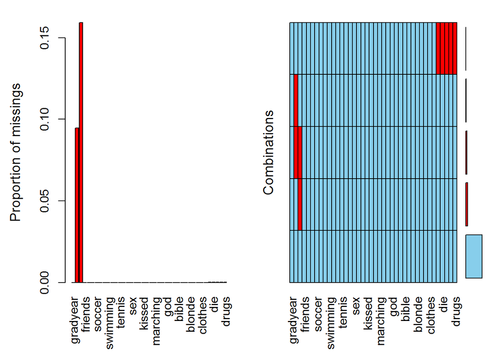

```
##
##  Missings per variable:
##      Variable Count
##      gradyear     0
##        gender  1428
##           age  2400
##       friends     0
##    basketball     0
##      football     0
##        soccer     0
##      softball     0
##    volleyball     0
##      swimming     0
##  cheerleading     0
##      baseball     0
##        tennis     0
##        sports     0
##          cute     0
##           sex     0
##          sexy     0
##           hot     0
##        kissed     0
##         dance     0
##          band     0
##      marching     0
##         music     0
##          rock     0
##           god     0
##        church     0
##         jesus     0
##         bible     0
##          hair     0
##         dress     0
##        blonde     0
##          mall     0
##      shopping     0
##       clothes     0
##     hollister     0
##   abercrombie     1
##           die     1
##         death     1
##         drunk     1
##         drugs     1
##
##  Missings in combinations of variables:
##                                                                     Combinations
##  0:0:0:0:0:0:0:0:0:0:0:0:0:0:0:0:0:0:0:0:0:0:0:0:0:0:0:0:0:0:0:0:0:0:0:0:0:0:0:0
##  0:0:0:0:0:0:0:0:0:0:0:0:0:0:0:0:0:0:0:0:0:0:0:0:0:0:0:0:0:0:0:0:0:0:0:1:1:1:1:1
##  0:0:1:0:0:0:0:0:0:0:0:0:0:0:0:0:0:0:0:0:0:0:0:0:0:0:0:0:0:0:0:0:0:0:0:0:0:0:0:0
##  0:1:0:0:0:0:0:0:0:0:0:0:0:0:0:0:0:0:0:0:0:0:0:0:0:0:0:0:0:0:0:0:0:0:0:0:0:0:0:0
##  0:1:1:0:0:0:0:0:0:0:0:0:0:0:0:0:0:0:0:0:0:0:0:0:0:0:0:0:0:0:0:0:0:0:0:0:0:0:0:0
##  Count    Percent
##  12206 80.9953550
##      1  0.0066357
##   1435  9.5222296
##    463  3.0723291
##    965  6.4034506
```

```r
library(VIM)
summary(aggr(market))
```

### Impute missing values

- "missForest"" is an implementation of random forest algorithm. It's a non parametric imputation method
- Non-parametric method does not make explicit assumptions about functional form of f (any arbitary function). Instead, it tries to estimate f such that it can be as close to the data points without seeming impractical.
- It builds a random forest model for each variable. Then it uses the model to predict missing values in the variable with the help of observed values.
- It yield OOB (out of bag) imputation error estimate. Moreover, it provides high level of control on imputation process. It has options to return OOB separately (for each variable) instead of aggregating over the whole data matrix. This helps to look more closely as to how accurately the model has imputed values for each variable.

```r
#install.packages("missForest")
library(missForest)
#install.packages("doParallel")
library(doParallel)
registerDoParallel(cores = 2)


#impute missing values, we can apply the 'missForest' function while breaking the work down into equal numbers of 'variables' or 'forests' for each core to work on (here we break the number of variables).

market.imp <- missForest(market, parallelize = "variables")
```

```
##   missForest iteration 1 in progress...done!
##   missForest iteration 2 in progress...done!
##   missForest iteration 3 in progress...done!
##   missForest iteration 4 in progress...done!
##   missForest iteration 5 in progress...done!
##   missForest iteration 6 in progress...done!
```

### Checking the output from "missforest"

```r
#check imputed values
market1 <- market.imp$ximp
head(market1)
```

```
##   gradyear gender      age friends basketball football soccer softball
## 1     2006      M 18.98200       7          0        0      0        0
## 2     2006      F 18.80100       0          0        1      0        0
## 3     2006      M 18.33500      69          0        1      0        0
## 4     2006      F 18.87500       0          0        0      0        0
## 5     2006      F 18.99500      10          0        0      0        0
## 6     2006      F 19.47841     142          0        0      0        0
##   volleyball swimming cheerleading baseball tennis sports cute sex sexy
## 1          0        0            0        0      0      0    0   0    0
## 2          0        0            0        0      0      0    1   0    0
## 3          0        0            0        0      0      0    0   0    0
## 4          0        0            0        0      0      0    1   0    0
## 5          0        0            0        0      0      0    0   1    0
## 6          0        0            0        0      0      0    0   1    0
##   hot kissed dance band marching music rock god church jesus bible hair
```

[output cut: 20 more lines]

```r
#check imputation error
market.imp$OOBerror
```

```
##       NRMSE         PFC
## 0.003621955 0.252089136
```

```r
#check for missing values
summary(market1)
```

```
##     gradyear    gender         age             friends
##  Min.   :2006   F:11497   Min.   :  3.086   Min.   :  0.00
##  1st Qu.:2006   M: 3573   1st Qu.: 17.733   1st Qu.:  2.00
##  Median :2007             Median : 18.256   Median : 18.00
##  Mean   :2007             Mean   : 18.783   Mean   : 28.28
##  3rd Qu.:2007             3rd Qu.: 18.778   3rd Qu.: 41.00
##  Max.   :2008             Max.   :106.927   Max.   :830.00
##    basketball         football           soccer           softball
##  Min.   : 0.0000   Min.   : 0.0000   Min.   : 0.0000   Min.   : 0.0000
##  1st Qu.: 0.0000   1st Qu.: 0.0000   1st Qu.: 0.0000   1st Qu.: 0.0000
##  Median : 0.0000   Median : 0.0000   Median : 0.0000   Median : 0.0000
##  Mean   : 0.2149   Mean   : 0.2322   Mean   : 0.1788   Mean   : 0.1271
##  3rd Qu.: 0.0000   3rd Qu.: 0.0000   3rd Qu.: 0.0000   3rd Qu.: 0.0000
##  Max.   :24.0000   Max.   :11.0000   Max.   :22.0000   Max.   :15.0000
##    volleyball         swimming        cheerleading        baseball
##  Min.   : 0.0000   Min.   : 0.0000   Min.   :0.00000   Min.   : 0.00000
##  1st Qu.: 0.0000   1st Qu.: 0.0000   1st Qu.:0.00000   1st Qu.: 0.00000
##  Median : 0.0000   Median : 0.0000   Median :0.00000   Median : 0.00000
##  Mean   : 0.1084   Mean   : 0.1165   Mean   :0.08826   Mean   : 0.09118
##  3rd Qu.: 0.0000   3rd Qu.: 0.0000   3rd Qu.:0.00000   3rd Qu.: 0.00000
##  Max.   :11.0000   Max.   :10.0000   Max.   :9.00000   Max.   :16.00000
##      tennis             sports             cute              sex
##  Min.   : 0.00000   Min.   : 0.0000   Min.   : 0.0000   Min.   :  0.0000
##  1st Qu.: 0.00000   1st Qu.: 0.0000   1st Qu.: 0.0000   1st Qu.:  0.0000
##  Median : 0.00000   Median : 0.0000   Median : 0.0000   Median :  0.0000
##  Mean   : 0.08607   Mean   : 0.1222   Mean   : 0.3047   Mean   :  0.2143
##  3rd Qu.: 0.00000   3rd Qu.: 0.0000   3rd Qu.: 0.0000   3rd Qu.:  0.0000
##  Max.   :13.00000   Max.   :12.0000   Max.   :18.0000   Max.   :114.0000
##       sexy              hot               kissed             dance
##  Min.   : 0.0000   Min.   : 0.00000   Min.   : 0.00000   Min.   : 0.0000
##  1st Qu.: 0.0000   1st Qu.: 0.00000   1st Qu.: 0.00000   1st Qu.: 0.0000
##  Median : 0.0000   Median : 0.00000   Median : 0.00000   Median : 0.0000
##  Mean   : 0.1223   Mean   : 0.09801   Mean   : 0.09356   Mean   : 0.3707
##  3rd Qu.: 0.0000   3rd Qu.: 0.00000   3rd Qu.: 0.00000   3rd Qu.: 0.0000
##  Max.   :18.0000   Max.   :10.00000   Max.   :26.00000   Max.   :30.0000
##       band           marching            music              rock
##  Min.   : 0.000   Min.   : 0.00000   Min.   : 0.0000   Min.   : 0.0000
##  1st Qu.: 0.000   1st Qu.: 0.00000   1st Qu.: 0.0000   1st Qu.: 0.0000
##  Median : 0.000   Median : 0.00000   Median : 0.0000   Median : 0.0000
##  Mean   : 0.297   Mean   : 0.04406   Mean   : 0.7226   Mean   : 0.2153
```

[output cut: 15 more lines]

```
##  Max.   :27.0000   Max.   :7.000   Max.   :327.0000   Max.   :11.0000
##     shopping        clothes         hollister        abercrombie
##  Min.   :0.000   Min.   :0.0000   Min.   :0.00000   Min.   :0.00000
##  1st Qu.:0.000   1st Qu.:0.0000   1st Qu.:0.00000   1st Qu.:0.00000
##  Median :0.000   Median :0.0000   Median :0.00000   Median :0.00000
##  Mean   :0.325   Mean   :0.1328   Mean   :0.05209   Mean   :0.03871
##  3rd Qu.:0.000   3rd Qu.:0.0000   3rd Qu.:0.00000   3rd Qu.:0.00000
##  Max.   :8.000   Max.   :8.0000   Max.   :9.00000   Max.   :6.00000
##       die              death             drunk             drugs
##  Min.   : 0.0000   Min.   : 0.0000   Min.   :0.00000   Min.   : 0.00000
##  1st Qu.: 0.0000   1st Qu.: 0.0000   1st Qu.:0.00000   1st Qu.: 0.00000
##  Median : 0.0000   Median : 0.0000   Median :0.00000   Median : 0.00000
##  Mean   : 0.1782   Mean   : 0.1146   Mean   :0.09577   Mean   : 0.05694
##  3rd Qu.: 0.0000   3rd Qu.: 0.0000   3rd Qu.:0.00000   3rd Qu.: 0.00000
##  Max.   :22.0000   Max.   :14.0000   Max.   :8.00000   Max.   :16.00000
```

Can infer that:

- The normalized root mean squared error (NRMSE; for continuous variables) is 0.3%
- And the second is the proportion falsely classified (PFC; for categorical variables) is 25%

```r
glimpse(market1)
```

```
## Observations: 15,070
## Variables: 40
## $ gradyear     <dbl> 2006, 2006, 2006, 2006, 2006, 2006, 2006, 2006, 2...
## $ gender       <fctr> M, F, M, F, F, F, F, M, F, F, F, F, F, M, F, M, ...
## $ age          <dbl> 18.98200, 18.80100, 18.33500, 18.87500, 18.99500,...
## $ friends      <dbl> 7, 0, 69, 0, 10, 142, 72, 17, 52, 39, 8, 21, 87, ...
## $ basketball   <dbl> 0, 0, 0, 0, 0, 0, 0, 0, 0, 0, 0, 0, 0, 0, 0, 0, 0...
## $ football     <dbl> 0, 1, 1, 0, 0, 0, 0, 0, 0, 0, 0, 1, 0, 0, 0, 0, 0...
## $ soccer       <dbl> 0, 0, 0, 0, 0, 0, 0, 0, 0, 0, 0, 0, 0, 0, 0, 0, 0...
## $ softball     <dbl> 0, 0, 0, 0, 0, 0, 0, 1, 0, 0, 0, 0, 0, 0, 0, 0, 0...
## $ volleyball   <dbl> 0, 0, 0, 0, 0, 0, 0, 0, 0, 0, 0, 0, 0, 0, 0, 0, 0...
## $ swimming     <dbl> 0, 0, 0, 0, 0, 0, 0, 0, 0, 0, 0, 0, 0, 0, 0, 0, 0...
## $ cheerleading <dbl> 0, 0, 0, 0, 0, 0, 0, 0, 0, 0, 0, 0, 0, 0, 0, 0, 0...
## $ baseball     <dbl> 0, 0, 0, 0, 0, 0, 0, 0, 0, 0, 0, 0, 0, 0, 0, 0, 0...
## $ tennis       <dbl> 0, 0, 0, 0, 0, 0, 0, 0, 0, 0, 0, 0, 0, 0, 0, 0, 0...
```

[output cut: 27 more lines]

Can infer that:

- From the above date, we can make out that other than 4 variables(gradyear, gender,age, friends) the rest all indicate interests/taste of the people.
- Thus, it would be logical to proceeded with these 36 variables for solving clustering problem.

### Normalising the data

```r
func_norm <- function(x)
{
  y <- (x-min(x))/(max(x)-min(x))
  return (y)
}


market2 <- market1[,5:40]

#market1_norm <- as.data.frame(scale(market2, center = TRUE, scale = TRUE))
market1_norm <- as.data.frame(sapply(market2,func_norm))
```

### Best K value (K means clustering)

```r
library(cluster)
```

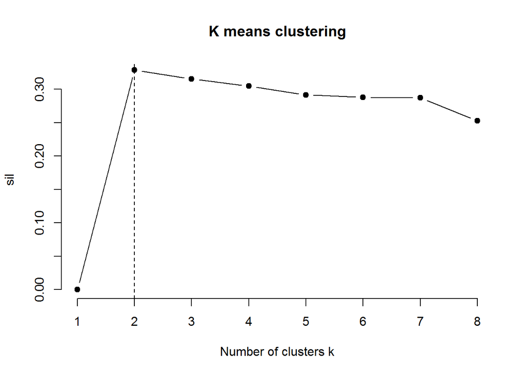

```r
k.max <- 8
data <- market1_norm
sil <- rep(0, k.max)
# Compute the average silhouette width for
# k = 2 to k = 8
for(i in 2:k.max){
  km.res <- kmeans(data, centers = i, nstart = 25,iter.max = 20)
  ss <- silhouette(km.res$cluster, dist(data,"manhattan"))
  sil[i] <- mean(ss[, 3])
}
# Plot the  average silhouette width
plot(1:k.max, sil, type = "b", pch = 19,
     frame = FALSE, xlab = "Number of clusters k",main='K means clustering')
abline(v = which.max(sil), lty = 2)
```

### Best K value (Hierarchical clustering)

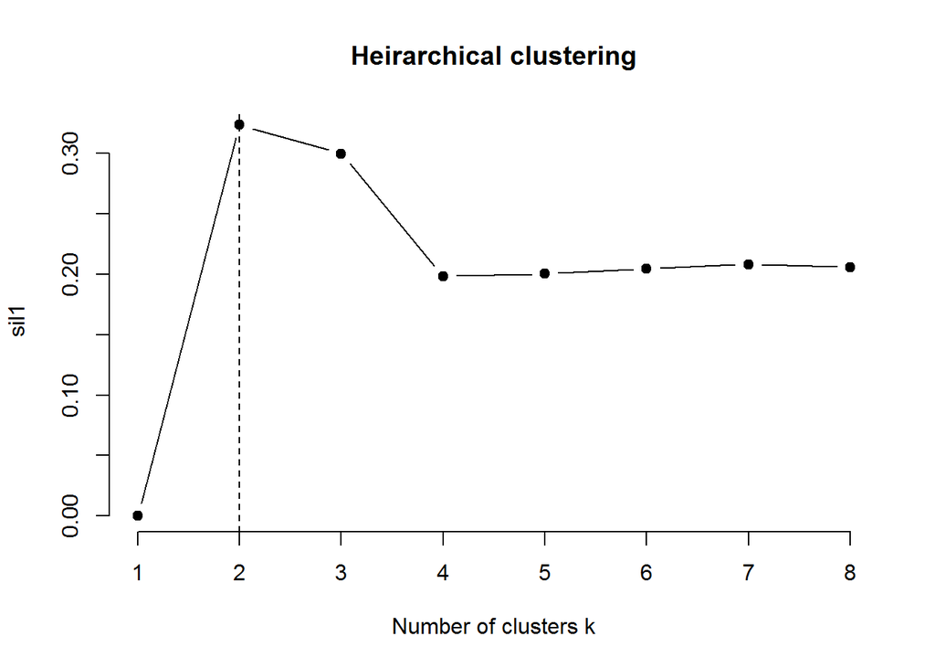

```r
library(cluster)
k.max <- 8
data <- market1_norm
sil1 <- rep(0, k.max)
# Compute the average silhouette width for
# k = 2 to k = 8
for(i in 2:k.max){
  hc.res <- hclust(dist(data),method = 'ward.D2')
  temp1 <- cutree(hc.res,i)
  ss <- silhouette(temp1, dist(data,"manhattan"))
  sil1[i] <- mean(ss[, 3])
}
# Plot the  average silhouette width
plot(1:k.max, sil1, type = "b", pch = 19,
     frame = FALSE, xlab = "Number of clusters k",main='Heirarchical clustering')
abline(v = which.max(sil1), lty = 2)
```

### Best K value (PAM clustering)

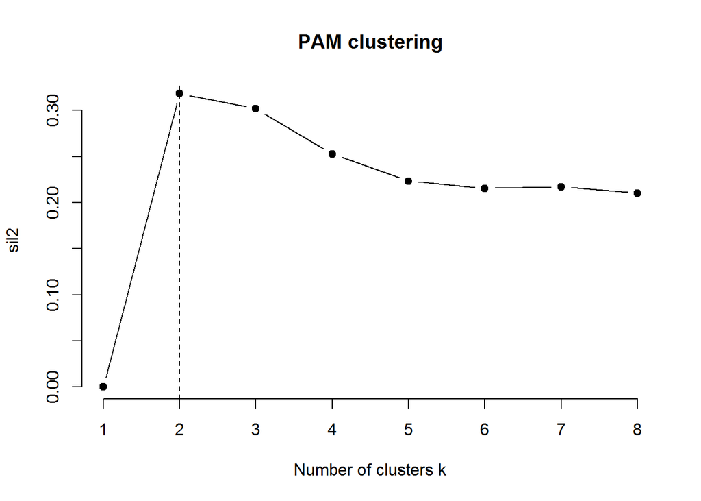

```r
library(cluster)
k.max <- 8
data <- market1_norm
sil2 <- rep(0, k.max)
# Compute the average silhouette width for
# k = 2 to k = 8
for(i in 2:k.max){
  pm.res <- pam(data, i)
  ss <- silhouette(pm.res$clustering, dist(data,"manhattan"))
  sil2[i] <- mean(ss[, 3])
}
# Plot the  average silhouette width
plot(1:k.max, sil2, type = "b", pch = 19,
     frame = FALSE, xlab = "Number of clusters k",main='PAM clustering')
abline(v = which.max(sil2), lty = 2)
```

### Avg. silhouette width of various models

```r
max(sil)  #k means (2 clusters)
```

```
## [1] 0.3284274
```

```r
max(sil1) # hierarchical (2 clusters)
```

```
## [1] 0.3235891
```

```r
max(sil2) # pam (2 clusters)
```

```
## [1] 0.3180791
```

### Choosing the best model

```r
max(sil,sil1,sil2)
```

```
## [1] 0.3284274
```

Can infer that:

- Thes best model is that of k means cluster with 2 clusters

### The best model

```r
data <- market1_norm

#hc.res <- hclust(dist(data),method = 'ward.D2')
km.res <- kmeans(data, centers = 2, nstart = 25,iter.max = 20)

#grouping into 2 clusters
groups.2 <- km.res$cluster

#number of records in each cluster
table(groups.2)
```

```
## groups.2
##     1     2
## 11366  3704
```

### Plotting silhouette values

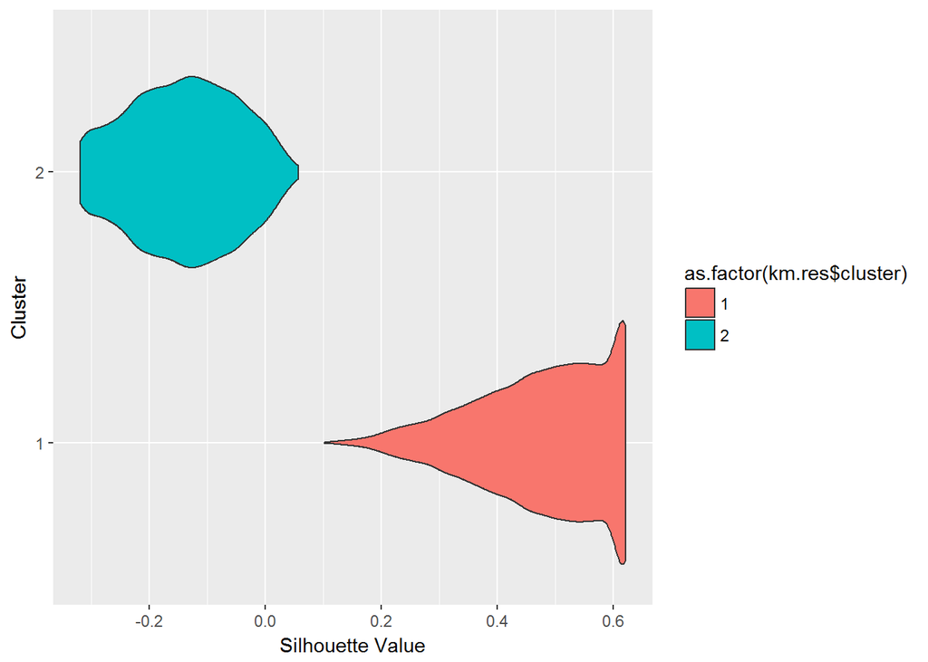

```r
ss <- silhouette(km.res$cluster, dist(data,"manhattan"))
ggplot(market1_norm,aes(as.factor(km.res$cluster),ss[,3],fill=as.factor(km.res$cluster)))+geom_violin()+coord_flip()+labs(y='Silhouette Value',x='Cluster',main='Silhouette Values for various clusters')
```

### Plotting (k means clustering)

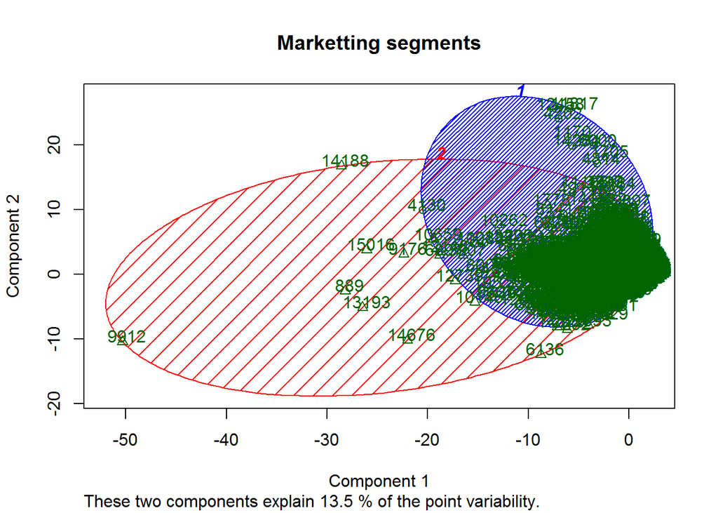

```r
#2D representation of the Segmentation

library(cluster)
clusplot(market1_norm, groups.2, color=TRUE, shade=TRUE, labels=2, lines=0, main= 'Marketting segments')
```

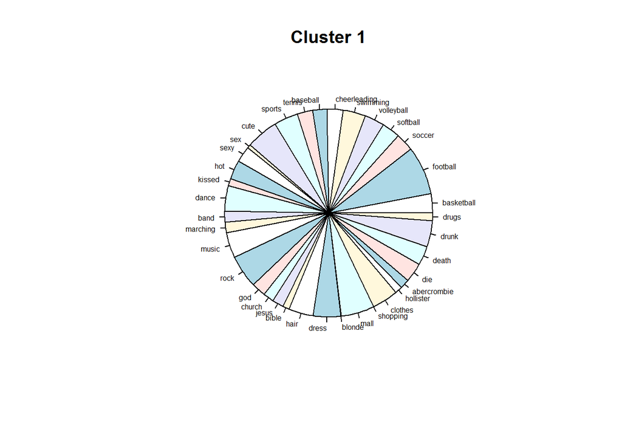

```r
#The cluster characterization using pie charts

pie(colSums(market1_norm[which(groups.2==1),]),cex=0.5,main='Cluster 1')
```

[figure not shown]

```r
pie(colSums(market1_norm[which(groups.2==2),]),cex=0.5,main='Cluster 2')
```